# Analyzing US-Government Gathered Data from the Vietnam War

## Ryan Brown

### Introduction

The goal of this project is to make use of data gathered by the United States Government and its allies throughout the first few years of the Vietnam War to explore what activities the enemy performed, and which time and to what success. The data in question is from the [Viet Cong Initiated Incidents Files](https://catalog.archives.gov/id/600133), otherwise known as "VCII," from 1 January 1965 to 31 December 1968. This data, collected and compiled by the Department of Defense (DoD) during the first few years of America's official war in the Republic of Vietnam, was used to determine how well pacification efforts were going in the various provinces of the Republic of Vietnam (RVN) and to track the activities of the enemy "Viet Cong," short for "Vietnamese Communists" which is meant to represent both North Vietnamese Army regulars and local Main Force insurgents as well as smaller-level local insurgent militias. This data, split into two large tables, contains an entry for every reported enemy (Viet Cong) initiated attack against the Republic of Vietnam, US forces, and their allies. With every entry comes a unique identifier, time and date of the incident, location (coordinates), number of enemy wounded, captured, or killed, number of friendlies wounded, captured, or killed, the country in which the incident occurred, and the type of activity committed by the Viet Cong (including combat, propaganda, terrorism, etc). My goal with this data is to import the data, which was helpfully changed from the old NIPS system to a tab-delimited format, sanitize it, remove unnecessary variables, change different indices and codes for locations to more readable values (ex: change Province values to the actual Province name in string format), merge both datasets together, and determine which province was the most violent (had the highest number of combat-related incidents) during 1968, one of the most crucial years of America's involvement in the Vietnam War.

### Background Information

Since this project can get heavy on historical and military lingo, I have included some phrases and their definition for additional context.

#### Corps

The Army of the Republic of Vietnam (ARVN) was split into four Corps, or a large collection of division-sized elements, which ran down the length of the country. These corps were used also as "Corps Tactical Zones" to represent which general area of the country one was talking about, with "I Corps" representing the northern-most provinces of South Vietnam which bordered warring North Vietnam, "II Corps" representing the large central highlands region of the country, "III Corps" representing the capital Saigon and key regions around the capital up to the Cambodian border, and "IV Corps," the region that is characterized by the delta of the massive Mekong River. Attached is a map taken from the [Wikipedia Article for I Corps] (https://en.wikipedia.org/wiki/I_Corps_(South_Vietnam)) which helps to provide some visual context, including the province names, for viewers.

[figure not shown]

We will begin this project by importing the necessary tools and the first half of the data file that we will be using to build our first dataframe. Then, using the read_csv tool (we use this tool because our data is in a character-delimited format), we import the data and tell the function that our data is separated by tabs ('\t'). Because the data can be a little troublesome based on whether it's read with the low_memory tag set to true or false, I will import twice to respective dataframes and pick and choose which columns I need later on based on what works.

```python
import pandas as pd
import numpy as np
```

```python
vc_file = 'VCIIA.AR.FIX.TAB'
vc_df = pd.read_csv(vc_file, sep = '\t', lineterminator = '\n', low_memory = False)
vc_df_low_mem = pd.read_csv(vc_file, sep = '\t', lineterminator = '\n', low_memory = True)
vc_df.head()
```

|  | SITRP | +PCN | +SC0 | VSZ | EKIAC | EWIAC | EPOWC | QUART | ZNDIV | XNAME | PROVN | REGON | CORPS | COORX | SDATE | STIME \r |
| --- | --- | --- | --- | --- | --- | --- | --- | --- | --- | --- | --- | --- | --- | --- | --- | --- |
| 0 | A5135034E | 0 |  | 0 | 0 | 0 | 0 | 4 | 02 | 1 | 03 | 05 | 1 | AT840460 | 651110 | 1300\r |
| 1 | A5139148E | 0 |  | 0 | 0 | 0 | 0 | 4 | 09 | 1 | 38 | 03 | 4 | XR242890 | 651130 | 2250\r |
| 2 | A5274001E | 0 |  | 0 | 0 | 0 | 0 | 3 | 01 | 1 | 01 | 11 | 1 | YD299556 | 650930 | 0000\r |
| 3 | A5274002E | 0 |  | 0 | 0 | 0 | 0 | 4 | 01 | 1 | 01 | 11 | 1 | YD346440 | 651001 | 1500\r |
| 4 | A5274003E | 0 |  | 0 | 0 | 0 | 0 | 3 | 01 | 1 | 02 | 11 | 1 | YD592294 | 650929 | 0000\r |

Now that we have imported the data into a Pandas dataframe, we can see that there is a lot that needs to be done to make the dataframe more readable and user-friendly. The first thing that I will do is remove all the blankspaces in the column names, as that makes accessing different variables very difficult. Now that I can access the names of different columns without having to worry about odd spacing, I can drop the columns +PCN, +SC0, and VSZ, which are variables that do not provide relevant information to this project. I then replace the main dataframe's SDATE (Date) column with the low-memory dataframe's Date column, since I encountered bugs when trying to use the low-memory = false version of the Date Series. Finally, I replace the column names with ones that are easier to read and make more sense to readers.

```python
# Transforming the dataframe to be more readable

# PCN, SC0, and VSZ are all variables that have nothing to do with the actual Viet Cong Incident Reports

vc_df.columns = vc_df.columns.str.replace(' ', '')
vc_df_low_mem.columns = vc_df_low_mem.columns.str.replace(' ', '')

vc_df.drop(columns = ['+PCN', '+SC0', 'VSZ'], inplace = True)

# replacing the main Date column with the low memory one, for some reason converting to datetime
# later on is much easier with the low memory version
vc_df['SDATE'] = vc_df_low_mem['SDATE']
vc_df.rename(columns = {'SITRP' : 'SITREP Number', 'EKIAC': 'Enemy KIA', 'EWIAC': 'Enemy Wounded', \
                        'EPOWC': 'Enemy Captured',\
                       'QUART': 'Year Quarter', 'ZNDIV': 'Division Indicator', 'XNAME': 'Country',\
                       'PROVN': 'Province', 'REGON': 'VC Region', 'CORPS': 'Corps', 'SDATE': 'Date',\
                       'COORX': 'Coordinates', 'STIME\r': 'Time'}, inplace = True)
```

Next up, I will be transforming all the entries Date and Time columns into Pandas "Datetime" format, which is a standardized time format within Pandas. To make the conversion from a string to datetime go smoother, I append the string '19' to the front of all the dates within the Date column to indicate that this data is taking place within the 20th century, and because the data only recorded the year up to the double digits, and datetime may get confused thinking that we are talking about data in the 21st century. The time string was also originally in the format ("####"), but I changed that to "(##:##") for readability. I then used the pd.to_datetime function to convert our Date column data into Pandas datetime, telling it that the format is Full year number, month, and day.

```python
# Formatting the date into datetime
for i in range(0, vc_df.shape[0]):
    vc_df.at[i, 'Date'] = '19' + str(vc_df.at[i, 'Date'])
    time = vc_df.at[i, 'Time']
    vc_df.at[i, 'Time'] = time[:2] + ':' + time[2:len(time) - 1]

# converting all dates to datetime, all dates that don't meet the format are changed to NaT
vc_df['Date'] = pd.to_datetime(vc_df['Date'], format = '%Y%m%d', errors = 'coerce')

vc_df.head()
```

|  | SITREP Number | Enemy KIA | Enemy Wounded | Enemy Captured | Year Quarter | Division Indicator | Country | Province | VC Region | Corps | Coordinates | Date | Time |
| --- | --- | --- | --- | --- | --- | --- | --- | --- | --- | --- | --- | --- | --- |
| 0 | A5135034E | 0 | 0 | 0 | 4 | 02 | 1 | 03 | 05 | 1 | AT840460 | 1965-11-10 | 13:00 |
| 1 | A5139148E | 0 | 0 | 0 | 4 | 09 | 1 | 38 | 03 | 4 | XR242890 | 1965-11-30 | 22:50 |
| 2 | A5274001E | 0 | 0 | 0 | 3 | 01 | 1 | 01 | 11 | 1 | YD299556 | 1965-09-30 | 00:00 |
| 3 | A5274002E | 0 | 0 | 0 | 4 | 01 | 1 | 01 | 11 | 1 | YD346440 | 1965-10-01 | 15:00 |
| 4 | A5274003E | 0 | 0 | 0 | 3 | 01 | 1 | 02 | 11 | 1 | YD592294 | 1965-09-29 | 00:00 |

Now, let's use the dataframe replace method to change the country represented by "1" in the Country column to read "RVN" and the country represented by "2" to display "DRV". I will now change the Province column to contain the names of the actual provinces in Vietnam instead of using numbers as representation. This index/conversion information comes from the original documentation of the VCII. Using a Python dictionary, I create a key/value pair for what the strings currently occupying the Province column are to the name of the Province they represent. I then use the dataframe replace method to replace all entries in the dataframe's Province column to the new names contained within the dictionary I just made.

```python
# Changing the Country labels and Province labels from numbers to strings

# Changing the country value of 1 to 'RVN' (Republic of Vietnam) and 2 to 'DRV' (Democratic Republic of Vietnam)
vc_df['Country'] = vc_df['Country'].replace(to_replace = '1', value = 'RVN')
vc_df['Country'] = vc_df['Country'].replace(to_replace = '2', value = 'DRV')

# Changing the province values to their names instead of numbers
vc_df.dtypes
provinces = {'00': 'Phuoc Thanh', '01': 'Quang Tri', '02': 'Thua Thien', '03': 'Quang Nam',\
             '04': 'Quang Tin', '05': 'Quang Ngai', '06': 'Binh Dinh', '07': 'Kontum',\
             '08': 'Pleiku', '09': 'Phu Bon', '10': 'Phu Yen', '11': 'Khanh Hoa', '12': 'Ninh Thuan',\
             '13': 'Darlac', '14': 'Quang Duc', '15': 'Tuyen Duc', '16': 'Lam Dong', '17': 'Binh Thuan',\
             '18': 'Binh Tuy', '19': 'Phuoc Long', '20': 'Sa Dec', '21': 'Binh Long', '22': 'Long Khanh',\
             '23': 'Phuoc Tuy', '24': 'Bien Hoa', '25': 'Tay Ninh', '26': 'Binh Duong', '27': 'Hua Nghia',\
             '28': 'Long An', '29': 'Gia Dinh', '30': 'Kien Tuong', '31': 'Dinh Tuong', '32': 'Co Cong', \
             '33': 'Kien Hoa', '34': 'Kien Phong', '35': 'Chau Doc', '36': 'An Giang', '37': 'Kien Giang', \
             '38': 'Vinh Binh', '39': 'Vinh Long', '40': 'Phong Dinh', '41': 'Chuong Thien', \
             '42': 'Ba Xuyen', '43': 'Bac Lieu', '44': 'An Xuyen', '45': 'Con Son Island'}
vc_df = vc_df.replace({'Province': provinces})
vc_df.head()
```

|  | SITREP Number | Enemy KIA | Enemy Wounded | Enemy Captured | Year Quarter | Division Indicator | Country | Province | VC Region | Corps | Coordinates | Date | Time |
| --- | --- | --- | --- | --- | --- | --- | --- | --- | --- | --- | --- | --- | --- |
| 0 | A5135034E | 0 | 0 | 0 | 4 | 02 | RVN | Quang Nam | 05 | 1 | AT840460 | 1965-11-10 | 13:00 |
| 1 | A5139148E | 0 | 0 | 0 | 4 | 09 | RVN | Vinh Binh | 03 | 4 | XR242890 | 1965-11-30 | 22:50 |
| 2 | A5274001E | 0 | 0 | 0 | 3 | 01 | RVN | Quang Tri | 11 | 1 | YD299556 | 1965-09-30 | 00:00 |
| 3 | A5274002E | 0 | 0 | 0 | 4 | 01 | RVN | Quang Tri | 11 | 1 | YD346440 | 1965-10-01 | 15:00 |
| 4 | A5274003E | 0 | 0 | 0 | 3 | 01 | RVN | Thua Thien | 11 | 1 | YD592294 | 1965-09-29 | 00:00 |

Next, we're going to work towards graphing the number of incidents by day, by province, and by corps over the time period 1965 to 1968. To do this, we create three empty dictionaries that correspond to each of these three variables. Making the data into dictionaries allows us to convert these dictionaries into dataframes easily later on. Using a for loop to index over every row, I grab that row's entry for Date, Province, and Corps, and add that entry to the dictionary, or if that entry already exists in the dictionary, I add one to the count of that incident entry.

```python
# Mapping VC incidents over time
daily_incidents = {}
province_incidents = {}
corps_incidents = {}

for i in range(0, vc_df.shape[0]):
    date_entry = vc_df['Date'].get(i)
    prov_entry = vc_df['Province'].get(i)
    corps_entry = vc_df['Corps'].get(i)

    if (date_entry in daily_incidents):
        daily_incidents[date_entry] += 1
    else:
        daily_incidents[date_entry] = 1

    if (prov_entry in province_incidents):
        province_incidents[prov_entry] += 1
    else:
        province_incidents[prov_entry] = 1

    if (corps_entry in corps_incidents):
        corps_incidents[corps_entry] += 1
    else:
        corps_incidents[corps_entry] = 1
```

With all those entries counted up, I now convert these dictionaries into three separate dataframes named "df_days", "df_provinces", and "df_corps". To clean these dataframes up, I drop some of the unnecessary columns that are created during conversion. I also sort the corps dataframe to read in ascending order. Using the .plot() function, I can now plot the targeted variable (province, day, or corps) vs. the number of incidents, which we calculated in the previous code block. The day vs. incidents plot will be a line graph, since that format shows the data clearly, and the other two plots seem to appear best as bar plots. I enlarged the province plot by using the fig_size parameter, since there are many provinces and the formatting would appear off if the graph was shrunken down to a smaller size.

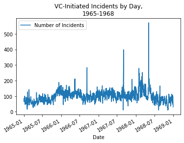

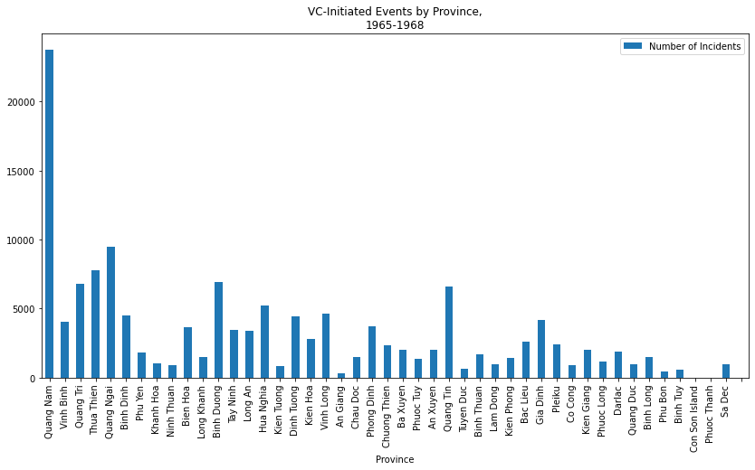

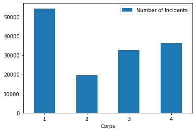

```python
# converting dictionary of dates to number of incidents to a list, easier to turn to a dataframe
df_days = pd.DataFrame(list(daily_incidents.items()), columns = ['Date', 'Number of Incidents'])
df_provinces = pd.DataFrame(list(province_incidents.items()), columns = ['Province', 'Number of Incidents'])
df_corps = pd.DataFrame(list(corps_incidents.items()), columns = ['Corps', 'Number of Incidents'])

# removing empty (null) entries (last rows) and sorting the Corps to be 1, 2, 3, 4
df_corps.drop(4, inplace = True)
df_provinces.drop(36, inplace = True)
df_corps.sort_values(by = 'Corps', axis = 0, inplace = True)

df_days.plot(x = 'Date', y = 'Number of Incidents', kind = 'line', \
             title = 'VC-Initiated Incidents by Day,\n1965-1968')
df_provinces.plot(x = 'Province', y = 'Number of Incidents', kind = 'bar', rot = 90, \
                  figsize = (14, 7), fontsize = 10, title = 'VC-Initiated Events by Province,\n1965-1968')
df_corps.plot(x = 'Corps', y = 'Number of Incidents', kind = 'bar', rot = 0)
```

These graphs are nice, but they capture a whole lot of time. Let's narrow that search down to a single year in the war - 1968. In addition, we will try to limit the incidents to only combat-related incidents. To know what type of incident each entry is, we need to bring in the second half of the data set and merge the two together. Using the same read_csv function, I read in the other .tab file, and do the same process of renaming columns as earlier.

```python
# importing the second table of data
vc_per1_file = 'VCIIA.AR.PER1.TAB'
vc_per1_df = pd.read_csv(vc_per1_file, sep = '\t', lineterminator = '\n', low_memory = True)

# suppressing future warnings for using append function
# found at: https://stackoverflow.com/questions/15777951/how-to-suppress-pandas-future-warning
import warnings
warnings.simplefilter(action='ignore', category=FutureWarning)

# renaming some of the columns and variables, dropping others
vc_per1_df.columns = vc_per1_df.columns.str.replace(' ', '')

vc_per1_df.drop(columns = ['+PCN', 'PSSQ1', 'VSZ1', 'FKIAC', 'FWIAC', 'FMIAC', \
                           'FUNIT', 'ESTRT', 'ESTRN'], inplace = True)
vc_per1_df.rename(columns = {'SITRP': 'SITREP Number', 'FKIAQ': 'Friendly KIA', \
                             'FWIAQ': 'Friendly Wounded', 'FMIAQ': 'Friendly MIA', \
                            'VCACT': 'VC Activity', 'VCOBJ\r': 'VC Objective'}, inplace = True)
vc_per1_df
```

|  | SITREP Number | Friendly KIA | Friendly Wounded | Friendly MIA | VC Activity | VC Objective |
| --- | --- | --- | --- | --- | --- | --- |
| 0 | A5135034E | 0 | 0 | 0 | P2 | \r |
| 1 | A5139148E | 0 | 0 | 0 | H2 | 11\r |
| 2 | A5274001E | 0 | 0 | 0 | M1 | 11\r |
| 3 | A5274001E | 0 | 0 | 0 | M5 | 74\r |
| 4 | A5274002E | 1 | 2 | 0 | H5 | 88\r |
| ... | ... | ... | ... | ... | ... | ... |
| 175379 | V5342034E | 0 | 1 | 0 | H2 | 88\r |
| 175380 | V5342035E | 0 | 0 | 0 | A3 | 88\r |
| 175381 | V5342036E | 0 | 1 | 0 | H2 | 88\r |
| 175382 | V5342037E | 0 | 0 | 0 | H2 | 88\r |
| 175383 | V5342038E | 0 | 0 | 0 | H2 | 88\r |

175384 rows × 6 columns

Now that we have our second-half dataframe set up, let's limit the incidents to only combat related incidents. How do I know which incident is combat-related? Using the old documentation which is attached to the files at the National Archive link above, I can decode the 'VC Activity' column (previously named 'VCACT') and select only the activities related to combat, which seems to be those with the prefix A and a number. I will now loop through all rows of the data frame and select only those with VC Activity entries that match A2 through A5 (there are no entries for A1, oddly enough). Each of the activities will be made into a separate dataframe, and we will merge the four together later (this process is slow, inefficient, and buggy, but I could not find a workaround without the compiler giving up or making mistakes).

```python
# limiting new dataframe to only "A2-5" VC activities, meaning direct combat
# there were no instances of A1
for i in range(0, vc_per1_df.shape[0]):
    vc_per1_df.at[i, 'VC Activity'] = str(vc_per1_df.at[i, 'VC Activity']).replace(' ', '')
df_combat_a2 = vc_per1_df[vc_per1_df['VC Activity'] == 'A2']
df_combat_a3 = vc_per1_df[vc_per1_df['VC Activity'] == 'A3']
df_combat_a4 = vc_per1_df[vc_per1_df['VC Activity'] == 'A4']
df_combat_a5 = vc_per1_df[vc_per1_df['VC Activity'] == 'A5']
```

I will now merge the four separate dataframes into one using an 'outer' merge. This combined dataframe is then 'inner merged' with the first half dataframe using the SITREP Number entry as index. This means that only the entries that relate to combat from the first half will be combined with the combat entries from the second half based on their common SITREP identification number.

```python
# outer merging a2 through a5 into one dataframe
df_combat = df_combat_a2.merge(df_combat_a3, how = 'outer')
df_combat = df_combat.merge(df_combat_a4, how = 'outer')
df_combat = df_combat.merge(df_combat_a5, how = 'outer')

# inner merging the original dataframe and the combat dataframe on sitrep number
df_combat = df_combat.merge(vc_df, how = 'inner', on = 'SITREP Number')
df_combat
```

|  | SITREP Number | Friendly KIA | Friendly Wounded | Friendly MIA | VC Activity | VC Objective | Enemy KIA | Enemy Wounded | Enemy Captured | Year Quarter | Division Indicator | Country | Province | VC Region | Corps | Coordinates | Date | Time |
| --- | --- | --- | --- | --- | --- | --- | --- | --- | --- | --- | --- | --- | --- | --- | --- | --- | --- | --- |
| 0 | A5339069E | 10 | 2 | 5 | A2 | 20\r | 0 | 0 | 0 | 4 | 10 | RVN | Long Khanh | 01 | 3 | YT595065 | 1965-12-05 | 00:45 |
| 1 | A6057086E | 8 | 8 | 10 | A2 | 83\r | 0 | 0 | 0 | 1 | 05 | RVN | Binh Duong | 01 | 3 | XT857240 | 1966-02-26 | 01:00 |
| 2 | A6143096E | 3 | 2 | 0 | A2 | 07\r | 0 | 0 | 0 | 2 | 09 | RVN | Kien Phong | 02 | 4 | WS929629 | 1966-05-23 | 00:40 |
| 3 | A6143096E | 3 | 2 | 0 | A2 | 07\r | 0 | 0 | 0 | 2 | 09 | RVN | Kien Phong | 02 | 4 | WS929629 | 1966-05-23 | 00:40 |
| 4 | A6196108E | 0 | 9 | 0 | A2 | 12\r | 0 | 0 | 0 | 3 | 09 | RVN | Vinh Binh | 03 | 4 | XR582934 | 1966-07-15 | 02:30 |
| ... | ... | ... | ... | ... | ... | ... | ... | ... | ... | ... | ... | ... | ... | ... | ... | ... | ... | ... |
| 9869 | C5271022E | 19 | 31 | 0 | A5 | 85\r | 0 | 0 | 0 | 3 | 22 | RVN | Binh Dinh | 05 | 2 | BR890890 | 1965-09-28 | 11:10 |
| 9870 | C5271041E | 1 | 37 | 4 | A5 | 85\r | 0 | 0 | 0 | 3 | 25 | RVN | Hua Nghia | 02 | 3 | XT554053 | 1965-09-28 | 01:40 |
| 9871 | C5271041E | 33 | 10 | 0 | A5 | 85\r | 0 | 0 | 0 | 3 | 25 | RVN | Hua Nghia | 02 | 3 | XT554053 | 1965-09-28 | 01:40 |
| 9872 | C5271047E | 12 | 11 | 9 | A5 | 10\r | 0 | 0 | 0 | 3 | 07 | RVN | Co Cong | 02 | 4 | XS907461 | 1965-09-28 | 03:00 |
| 9873 | C5271047E | 3 | 1 | 1 | A5 | 10\r | 0 | 0 | 0 | 3 | 07 | RVN | Co Cong | 02 | 4 | XS907461 | 1965-09-28 | 03:00 |

9874 rows × 18 columns

Before getting to some more graphing, I will clean up the data a little more. In this code block, I am removing the return carriage symbol that made it into the VC Objective entries and limiting the columns of the massive combined dataframe to only those that I need. I also switch out the activities "A#" code for the string of the activity. Finally, the massive dataframe is limited to only entries with the year 1968, and the indexing is reset so all the index values are sequential.

```python
# some final cleaning up of the combat dataframe before doing EDA
# removing the \r from VC Objective
for i in range(0, df_combat.shape[0]):
    df_combat.at[i, 'VC Objective'] = df_combat.at[i, 'VC Objective'][:-1]

# reorganizing the columns and removing Country (all data is now taking place in South Vietnam)
# as well as removing Division Indicator, as it is beyond the scope of this project
# source: https://stackoverflow.com/questions/13148429/how-to-change-the-order-of-dataframe-columns
df_combat = df_combat[['SITREP Number', 'Date', 'Time', 'Province', 'Corps', 'VC Region', 'Coordinates',\
                        'VC Activity', 'VC Objective', 'Enemy KIA', 'Enemy Wounded', \
                       'Enemy Captured', 'Friendly KIA', 'Friendly Wounded', 'Friendly MIA']]

# replacing the VC Activity with its corresponding string
activities = {'A2': 'Attack', 'A3': 'Ambush', 'A4': 'Engagement', 'A5': 'Assault'}
df_combat = df_combat.replace({'VC Activity': activities})

# we're going to limit the scope to only 1968, a critical point in the war
df_combat_68 = df_combat[df_combat['Date'].dt.year == 1968]

# finally, we're gonna reset the indices to be sequential
new_index = np.arange(df_combat_68.shape[0])
df_combat_68 = df_combat_68.set_index(new_index)
df_combat_68.head()
```

|  | SITREP Number | Date | Time | Province | Corps | VC Region | Coordinates | VC Activity | VC Objective | Enemy KIA | Enemy Wounded | Enemy Captured | Friendly KIA | Friendly Wounded | Friendly MIA |
| --- | --- | --- | --- | --- | --- | --- | --- | --- | --- | --- | --- | --- | --- | --- | --- |
| 0 | A8001211E | 1968-01-01 | 20:20 | Tay Ninh | 3 | 01 | XT084816 | Attack | 18 | 0 | 0 | 0 | 0 | 0 | 0 |
| 1 | A8001212E | 1968-01-01 | 20:52 | Tay Ninh | 3 | 01 | XT499806 | Attack | 12 | 0 | 0 | 0 | 0 | 0 | 0 |
| 2 | A8001270E | 1968-01-01 | 19:30 | Dinh Tuong | 4 | 02 | WS980490 | Attack | 88 | 0 | 0 | 0 | 0 | 0 | 0 |
| 3 | A8001275E | 1968-01-01 | 11:15 | Kien Giang | 4 | 03 | WR141907 | Attack | 11 | 3 | 0 | 0 | 0 | 0 | 0 |
| 4 | A8002029E | 1968-01-02 | 00:25 | Tay Ninh | 3 | 01 | XT384856 | Attack | 88 | 0 | 0 | 0 | 0 | 0 | 0 |

Using the same dictionary process as before, dataframes for date, province, and corps vs. number of incidents are created. The plots are then created from these dataframes, same as before.

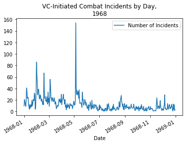

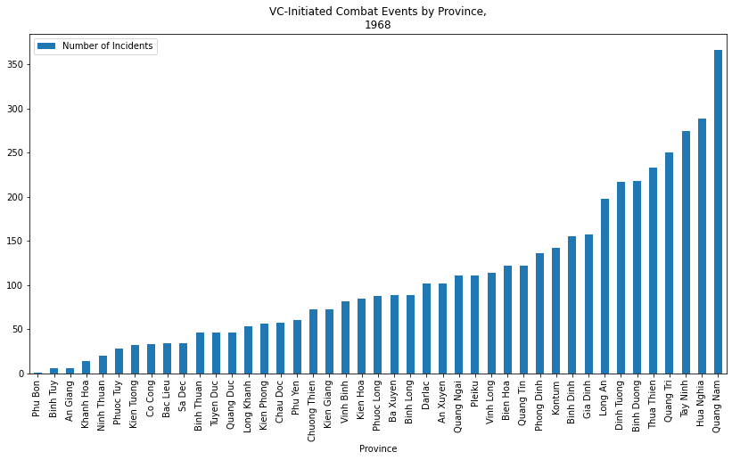

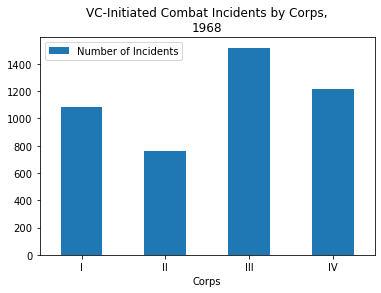

```python
# Mapping VC combat incidents over time
daily_incidents = {}
province_incidents = {}
corps_incidents = {}

for i in range(0, df_combat_68.shape[0]):
    date_entry = df_combat_68['Date'].get(i)
    prov_entry = df_combat_68['Province'].get(i)
    corps_entry = df_combat_68['Corps'].get(i)

    if (date_entry in daily_incidents):
        daily_incidents[date_entry] += 1
    else:
        daily_incidents[date_entry] = 1

    if (prov_entry in province_incidents):
        province_incidents[prov_entry] += 1
    else:
        province_incidents[prov_entry] = 1

    if (corps_entry in corps_incidents):
        corps_incidents[corps_entry] += 1
    else:
        corps_incidents[corps_entry] = 1

# converting dictionary of dates to number of incidents to a list, easier to turn to a dataframe
df_days = pd.DataFrame(list(daily_incidents.items()), columns = ['Date', 'Number of Incidents'])
df_provinces = pd.DataFrame(list(province_incidents.items()), columns = ['Province', 'Number of Incidents'])
df_corps = pd.DataFrame(list(corps_incidents.items()), columns = ['Corps', 'Number of Incidents'])

# ordering the province dataframe by number of incidents
df_provinces.sort_values(by = 'Number of Incidents', axis = 0, inplace = True)
df_provinces.drop(index = 42, inplace = True)

# removing empty (null) entries (last rows) and sorting the Corps to be 1, 2, 3, 4
df_corps.drop(4, inplace = True)
df_provinces.drop(36, inplace = True)
df_corps.sort_values(by = 'Corps', axis = 0, inplace = True)

# replacing 1, 2, 3, 4 corps with roman numerals (as they were written during the war)
corps_numerals = {'1': 'I', '2': 'II', '3': 'III', '4': 'IV'}
df_corps = df_corps.replace({'Corps': corps_numerals})

df_days.plot(x = 'Date', y = 'Number of Incidents', kind = 'line', \
             title = 'VC-Initiated Combat Incidents by Day,\n1968')
df_provinces.plot(x = 'Province', y = 'Number of Incidents', kind = 'bar', rot = 90, \
                  figsize = (14, 7), fontsize = 10, title = 'VC-Initiated Combat Events by Province,\n1968')
df_corps.plot(x = 'Corps', y = 'Number of Incidents', kind = 'bar', rot = 0, \
              title = 'VC-Initiated Combat Incidents by Corps,\n1968')
```

### Conclusions

Looking at the combat incidents by day graph, we can see that there is an insane spike of events that occurs in May. This may correspond to the [Mini Tet Offensive] (https://en.wikipedia.org/wiki/May_offensive), but a spike in incidents of this scale seems to be abnormal. Other than that spike in May, we can see that the first few months of 1968 were full of combat-related incidents, which correspond to the famous [Tet Offensive] (https://en.wikipedia.org/wiki/Tet_Offensive) of 1968. This offensive saw most population centers and military installations throughout South Vietnam targetted by North Vietnamese soldiers or local South Vietnamese Communist forces. The province graph seems to show that the five most "active" provinces of South Vietnam are Quang Nam, Hua Nghia, Tay Ninh, Quang Tri, and Thua Thien. Quang Nam, Quang Tri, and Thua Thien are the three northern-most provinces of South Vietnam and were the sites of many violent battles during the course of the Tet Offensive. Tay Ninh and Hua Nghia are two provinces between the capital of Saigon and the Cambodian border. Finally, a simple graph of counting incidents by corps shows that III Corps had the most incidents tallied overall, IV Corps follows behind, then I and II Corps. I personally know very little about the course of the war in IV Corps, but it always struck me as a less active, or possibly less-covered, theater of the war. I will be sure to put more research into how the war developed in the Mekong Delta region as a result of this data analysis!